# Communicate Data Findings for the dataset Baywheels Bike

## by Steven Melendez Lara

- 1 - Introduction
- 2 - Clean the data
- 3 - Univariate Exploration
- 4 - Bivariate Exploration
- 5 - Multivariate Exploration
- 6 - Summary
- 7 - References

```python
from IPython.display import Image
Image(url = 'https://images.ctfassets.net/q8mvene1wzq4/1JcJbMWq11j1xFsXasT3Yl/fdd7b5659a4cc203a47ba59a5a11bee1/5_park_docked-watson_object_id_0_2_0113.png?w=1500', width = 300, height = 150)
```

[figure not shown]

## 1 - Introduction

Ford GoBike is the Bay Area's bike share system. Bay Area Bike Share was introduced in 2013 as a pilot program for the region, with 700 bikes and 70 stations across San Francisco and San Jose. Once expansion is complete, Ford GoBike will grow to 7,000 bikes across San Francisco, the East Bay and San Jose.

Ford GoBike, like other bike share systems, consists of a fleet of specially designed, sturdy and durable bikes that are locked into a network of docking stations throughout the city. The bikes can be unlocked from one station and returned to any other station in the system, making them ideal for one-way trips. People use bike share to commute to work or school, run errands, get to appointments or social engagements and more. It's a fun, convenient and affordable way to get around.

The bikes are available for use 24 hours/day, 7 days/week, 365 days/year and riders have access to all bikes in the network when they become a member or purchase a pass.

## 1.1 - Preliminary Wrangling

The data includes information about individual rides made in a bike-sharing system covering the greater San Francisco Bay area. The data is from 2019. The total amount of data is 2.506.983 rides.

The list of documents that I will use for this analysis can be found in this [page](https://s3.amazonaws.com/baywheels-data/index.html).

Data is saved in different documents, as a result all documents shall be downloaded programmatically and then combined in one single file.

```python
# import warnings filter
from warnings import simplefilter
# ignore all future warnings
simplefilter(action='ignore', category=FutureWarning)
```

```python
# import all packages and set plots to be embedded inline
import pandas as pd
import numpy as np
import random
import matplotlib.pyplot as plt
import requests
import json
import zipfile
import os
import seaborn as sns
import calendar

%matplotlib inline
```

```python
# Create list of months for first 4 months of 2019
list_years1 = list(range(201901,201905))
list_years1
```

```
[201901, 201902, 201903, 201904]
```

```python
# Create list of months for the last 8 months of 2019
list_years2 = list(range(201905,201913))
list_years2
```

```
[201905, 201906, 201907, 201908, 201909, 201910, 201911, 201912]
```

```python
# Create list of urls to download the data
list_urls = []

# Add the url for list_years1
for year in list_years1:
    list_urls.append("https://s3.amazonaws.com/baywheels-data/{}-fordgobike-tripdata.csv.zip".format(year))

for year in list_years2:
    list_urls.append("https://s3.amazonaws.com/baywheels-data/{}-baywheels-tripdata.csv.zip".format(year))

# Show the 2019's URLs
list_urls
```

```
['https://s3.amazonaws.com/baywheels-data/201901-fordgobike-tripdata.csv.zip',
 'https://s3.amazonaws.com/baywheels-data/201902-fordgobike-tripdata.csv.zip',
 'https://s3.amazonaws.com/baywheels-data/201903-fordgobike-tripdata.csv.zip',
 'https://s3.amazonaws.com/baywheels-data/201904-fordgobike-tripdata.csv.zip',
 'https://s3.amazonaws.com/baywheels-data/201905-baywheels-tripdata.csv.zip',
 'https://s3.amazonaws.com/baywheels-data/201906-baywheels-tripdata.csv.zip',
 'https://s3.amazonaws.com/baywheels-data/201907-baywheels-tripdata.csv.zip',
 'https://s3.amazonaws.com/baywheels-data/201908-baywheels-tripdata.csv.zip',
 'https://s3.amazonaws.com/baywheels-data/201909-baywheels-tripdata.csv.zip',
 'https://s3.amazonaws.com/baywheels-data/201910-baywheels-tripdata.csv.zip',
 'https://s3.amazonaws.com/baywheels-data/201911-baywheels-tripdata.csv.zip',
 'https://s3.amazonaws.com/baywheels-data/201912-baywheels-tripdata.csv.zip']
```

```python
# Create a function to download, extract and read the data
def get_data(url):

    # Import the data programmatically using 'requests'
    r = requests.get(url)

    # Create empty dataframe
    df = pd.DataFrame()

    # Name of the zip file
    name_zip_file = url.split('/')[-1]

    # Name of the CSV file
    name_file = name_zip_file.split('.')[0] + ".csv"

    # Save the data in the current directory
    with open (name_zip_file, 'wb') as file:

        # Save the ZIP file
        file.write(r.content)

        # Unzip the zip file
        zf = zipfile.ZipFile(name_zip_file)

        # Read the CSV file and save the result in a dataframe
        df = pd.read_csv(zf.open(name_file))

        # Before returning the data I will remove the column "rental_access_method" if it exist
        if 'rental_access_method' in df.columns:
            df.drop('rental_access_method', axis = 1, inplace = True)

        # Before returning the data I will remove the column "bike_share_for_all_trip" if it exist
        if 'bike_share_for_all_trip' in df.columns:
            df.drop('bike_share_for_all_trip', axis = 1, inplace = True)

    # Return the dataframe
    return(df)
```

```python
# Create a empty dataframe
bike_data = pd.DataFrame()

for url in list_urls:
    # Add the data to the main dataframe called "bike_data"
    bike_data = bike_data.append(get_data(url))

# Save all the data (backup) in a CSV file
bike_data.to_csv('bike_data.csv', encoding = 'utf-8', index=False)
```

```python
# Save the new file
bike_data = pd.read_csv('bike_data.csv')
```

```python
# Show the header of "bike_data"
bike_data.head()
```

|  | duration_sec | start_time | end_time | start_station_id | start_station_name | start_station_latitude | start_station_longitude | end_station_id | end_station_name | end_station_latitude | end_station_longitude | bike_id | user_type |
| --- | --- | --- | --- | --- | --- | --- | --- | --- | --- | --- | --- | --- | --- |
| 0 | 80825 | 2019-01-31 17:57:44.6130 | 2019-02-01 16:24:49.8640 | 229.0 | Foothill Blvd at 42nd Ave | 37.775745 | -122.213037 | 196.0 | Grand Ave at Perkins St | 37.808894 | -122.256460 | 4861 | Subscriber |
| 1 | 65900 | 2019-01-31 20:58:33.8860 | 2019-02-01 15:16:54.1730 | 4.0 | Cyril Magnin St at Ellis St | 37.785881 | -122.408915 | 134.0 | Valencia St at 24th St | 37.752428 | -122.420628 | 5506 | Subscriber |
| 2 | 62633 | 2019-01-31 18:06:52.9240 | 2019-02-01 11:30:46.5300 | 245.0 | Downtown Berkeley BART | 37.870139 | -122.268422 | 157.0 | 65th St at Hollis St | 37.846784 | -122.291376 | 2717 | Customer |
| 3 | 44680 | 2019-01-31 19:46:09.7190 | 2019-02-01 08:10:50.3180 | 85.0 | Church St at Duboce Ave | 37.770083 | -122.429156 | 53.0 | Grove St at Divisadero | 37.775946 | -122.437777 | 4557 | Customer |
| 4 | 60709 | 2019-01-31 14:19:01.5410 | 2019-02-01 07:10:51.0650 | 16.0 | Steuart St at Market St | 37.794130 | -122.394430 | 28.0 | The Embarcadero at Bryant St | 37.787168 | -122.388098 | 2100 | Customer |

```python
# Show bike_data shape
bike_data.shape
```

```
(2506983, 13)
```

```python
# Show bike_data basic statistics
bike_data.describe()
```

|  | duration_sec | start_station_id | start_station_latitude | start_station_longitude | end_station_id | end_station_latitude | end_station_longitude | bike_id |
| --- | --- | --- | --- | --- | --- | --- | --- | --- |
| count | 2.506983e+06 | 2.426249e+06 | 2.506983e+06 | 2.506983e+06 | 2.424081e+06 | 2.506983e+06 | 2.506983e+06 | 2.506983e+06 |
| mean | 8.076483e+02 | 1.465047e+02 | 3.776506e+01 | -1.223499e+02 | 1.427044e+02 | 3.776422e+01 | -1.223459e+02 | 2.789833e+04 |
| std | 1.974714e+03 | 1.223171e+02 | 1.363698e-01 | 3.089648e-01 | 1.214296e+02 | 2.392885e-01 | 7.080417e-01 | 1.146067e+05 |
| min | 6.000000e+01 | 3.000000e+00 | 0.000000e+00 | -1.225143e+02 | 3.000000e+00 | 0.000000e+00 | -1.225143e+02 | 4.000000e+00 |
| 25% | 3.590000e+02 | 4.700000e+01 | 3.776931e+01 | -1.224130e+02 | 4.300000e+01 | 3.777003e+01 | -1.224117e+02 | 1.952000e+03 |
| 50% | 5.710000e+02 | 1.050000e+02 | 3.778053e+01 | -1.223983e+02 | 1.010000e+02 | 3.778076e+01 | -1.223981e+02 | 4.420000e+03 |
| 75% | 8.870000e+02 | 2.430000e+02 | 3.779539e+01 | -1.222914e+02 | 2.390000e+02 | 3.779587e+01 | -1.222934e+02 | 9.682000e+03 |
| max | 9.121100e+05 | 4.980000e+02 | 4.551000e+01 | 0.000000e+00 | 4.980000e+02 | 4.551000e+01 | 0.000000e+00 | 9.999410e+05 |

```python
# Show bike_data info
bike_data.info()
```

```
<class 'pandas.core.frame.DataFrame'>
RangeIndex: 2506983 entries, 0 to 2506982
Data columns (total 13 columns):
 #   Column                   Dtype
---  ------                   -----
 0   duration_sec             int64
 1   start_time               object
 2   end_time                 object
 3   start_station_id         float64
 4   start_station_name       object
 5   start_station_latitude   float64
 6   start_station_longitude  float64
 7   end_station_id           float64
 8   end_station_name         object
 9   end_station_latitude     float64
 10  end_station_longitude    float64
 11  bike_id                  int64
 12  user_type                object
dtypes: float64(6), int64(2), object(5)
memory usage: 248.6+ MB
```

```python
# Check null values
bike_data.info(null_counts = True)
```

```
<class 'pandas.core.frame.DataFrame'>
RangeIndex: 2506983 entries, 0 to 2506982
Data columns (total 13 columns):
 #   Column                   Non-Null Count    Dtype
---  ------                   --------------    -----
 0   duration_sec             2506983 non-null  int64
 1   start_time               2506983 non-null  object
 2   end_time                 2506983 non-null  object
 3   start_station_id         2426249 non-null  float64
 4   start_station_name       2426850 non-null  object
 5   start_station_latitude   2506983 non-null  float64
 6   start_station_longitude  2506983 non-null  float64
 7   end_station_id           2424081 non-null  float64
 8   end_station_name         2424633 non-null  object
 9   end_station_latitude     2506983 non-null  float64
 10  end_station_longitude    2506983 non-null  float64
 11  bike_id                  2506983 non-null  int64
 12  user_type                2506983 non-null  object
dtypes: float64(6), int64(2), object(5)
memory usage: 248.6+ MB
```

```python
# Check duplicates
bike_data.duplicated().sum()
```

```
0
```

```python
# Check for Na's
bike_data.isna().sum()
```

```
duration_sec                   0
start_time                     0
end_time                       0
start_station_id           80734
start_station_name         80133
start_station_latitude         0
start_station_longitude        0
end_station_id             82902
end_station_name           82350
end_station_latitude           0
end_station_longitude          0
bike_id                        0
user_type                      0
dtype: int64
```

### What is the structure of your dataset?

In the dataframe `bike_data` there are in total 2,506,983 entries and 13 features (`duration_sec`, `start_time`, `end_time`, `start_station_id`, `start_station_name`, `start_station_latitude`, `start_station_longitude`, `end_station_id`, `end_station_name`, `end_station_latitude`, `end_station_longitude`, `bike_id`,`user_type`).

Most of the variables are numeric except for the start_station_name, end_station_name and user type.

### What is/are the main feature(s) of interest in your dataset?

I have special interest in start and end of rides. Users characteristics between `Customer` and `Subscriber`, day of weeks with high usage. The main goal is to identify the customer comsumption patterns of bike riding.

### What features in the dataset do you think will help support your investigation into your feature(s) of interest?

The start and end times, and related time-based information will be utilized heavily. I will use the customer related data, as well as the distance to understand the user-driven data behind each ride to gain more `Subscribers`.

## 2 - Clean the data

Before to conduct any EDA, the data must be cleaned as much as we can.

```python
# Create a copy of the original bike_data
bike_data_original = bike_data.copy()
```

Entries without start or end station will be removed from the dataframe.

```python
# Check the number of rows in where the stations ID are na's
sum(bike_data.start_station_id.isna()), sum(bike_data.end_station_id.isna())
```

```
(80734, 82902)
```

```python
# Remove the rows without station id
bike_data = bike_data[~bike_data.start_station_id.isna()]
bike_data = bike_data[~bike_data.end_station_id.isna()]
```

```python
# Change datatypes of dates
bike_data['start_time'] = pd.to_datetime(bike_data['start_time'])
bike_data['end_time'] = pd.to_datetime(bike_data['end_time'])

# Change the datatypes of the ids from int to string
bike_data['start_station_id'] = bike_data['start_station_id'].astype(int).astype(str)
bike_data['end_station_id'] = bike_data['end_station_id'].astype(int).astype(str)
bike_data['bike_id'] = bike_data['bike_id'].astype(str)

# Calculate the duration in hours
bike_data['duration_hour'] = bike_data['duration_sec']/3600

# Get the day, month, year, hour from the start and end time
bike_data['start_year'] = bike_data['start_time'].apply(lambda x: x.year)
bike_data['start_month'] = bike_data['start_time'].apply(lambda x: x.month)
bike_data['start_day'] = bike_data['start_time'].apply(lambda x: x.day)
bike_data['start_hour'] = bike_data['start_time'].apply(lambda x: x.hour)
bike_data['end_year'] = bike_data['end_time'].apply(lambda x: x.year)
bike_data['end_month'] = bike_data['end_time'].apply(lambda x: x.month)
bike_data['end_day'] = bike_data['end_time'].apply(lambda x: x.day)
bike_data['end_hour'] = bike_data['end_time'].apply(lambda x: x.hour)
```

```python
# Function to get the month name from the month number
def get_month_name(month):
    list_months = ['Jan', 'Feb', 'Mar', 'Apr', 'May', 'Jun', 'Jul', 'Aug', 'Sep', 'Oct', 'Nov', 'Dec']
    return(list_months[month-1])

# Create new column with the name of the month
bike_data['start_month_name'] = bike_data['start_month'].apply(lambda month: get_month_name(month))
bike_data['end_month_name'] = bike_data['end_month'].apply(lambda month: get_month_name(month))
```

```python
# Calculate Start time weekday
bike_data['start_time_weekday'] = bike_data['start_time'].dt.strftime('%a')
```

```python
# Calculate Duration in minutes
bike_data['duration_min'] = bike_data['duration_sec']/60
bike_data['duration_min'] = bike_data['duration_min'].astype(int)
```

```python
# Show the header of "bike_data" with transformations
bike_data.head()
```

|  | duration_sec | start_time | end_time | start_station_id | start_station_name | start_station_latitude | start_station_longitude | end_station_id | end_station_name | end_station_latitude | ... | start_day | start_hour | end_year | end_month | end_day | end_hour | start_month_name | end_month_name | start_time_weekday | duration_min |
| --- | --- | --- | --- | --- | --- | --- | --- | --- | --- | --- | --- | --- | --- | --- | --- | --- | --- | --- | --- | --- | --- |
| 0 | 80825 | 2019-01-31 17:57:44.613 | 2019-02-01 16:24:49.864 | 229 | Foothill Blvd at 42nd Ave | 37.775745 | -122.213037 | 196 | Grand Ave at Perkins St | 37.808894 | ... | 31 | 17 | 2019 | 2 | 1 | 16 | Jan | Feb | Thu | 1347 |
| 1 | 65900 | 2019-01-31 20:58:33.886 | 2019-02-01 15:16:54.173 | 4 | Cyril Magnin St at Ellis St | 37.785881 | -122.408915 | 134 | Valencia St at 24th St | 37.752428 | ... | 31 | 20 | 2019 | 2 | 1 | 15 | Jan | Feb | Thu | 1098 |
| 2 | 62633 | 2019-01-31 18:06:52.924 | 2019-02-01 11:30:46.530 | 245 | Downtown Berkeley BART | 37.870139 | -122.268422 | 157 | 65th St at Hollis St | 37.846784 | ... | 31 | 18 | 2019 | 2 | 1 | 11 | Jan | Feb | Thu | 1043 |
| 3 | 44680 | 2019-01-31 19:46:09.719 | 2019-02-01 08:10:50.318 | 85 | Church St at Duboce Ave | 37.770083 | -122.429156 | 53 | Grove St at Divisadero | 37.775946 | ... | 31 | 19 | 2019 | 2 | 1 | 8 | Jan | Feb | Thu | 744 |
| 4 | 60709 | 2019-01-31 14:19:01.541 | 2019-02-01 07:10:51.065 | 16 | Steuart St at Market St | 37.794130 | -122.394430 | 28 | The Embarcadero at Bryant St | 37.787168 | ... | 31 | 14 | 2019 | 2 | 1 | 7 | Jan | Feb | Thu | 1011 |

5 rows × 26 columns

```python
# Show the information of "bike_data" after changing some data types
bike_data.info()
```

```
<class 'pandas.core.frame.DataFrame'>
Int64Index: 2407259 entries, 0 to 2506660
Data columns (total 26 columns):
 #   Column                   Dtype
---  ------                   -----
 0   duration_sec             int64
 1   start_time               datetime64[ns]
 2   end_time                 datetime64[ns]
 3   start_station_id         object
 4   start_station_name       object
 5   start_station_latitude   float64
 6   start_station_longitude  float64
 7   end_station_id           object
 8   end_station_name         object
 9   end_station_latitude     float64
```

[output cut: 18 more lines]

```python
# Save the clean version of bike_data
bike_data.to_csv('bike_data_clean.csv', encoding = 'utf-8', index=False)
```

## 3 - Univariate Exploration

In this section, the distributions of individual variables will be analyzed

```python
# Removing the rainbow colors and setting to the variable no_color
no_color = sns.color_palette()[0]
```

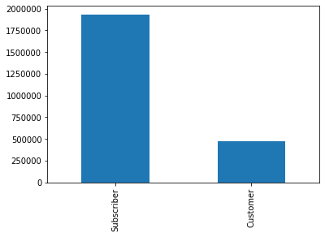

```python
# Check the amount of user type
bike_data.user_type.value_counts().plot(kind='bar');
```

This chart indicates that `Subscriber` user type higher when is compared to `Customer` user type.

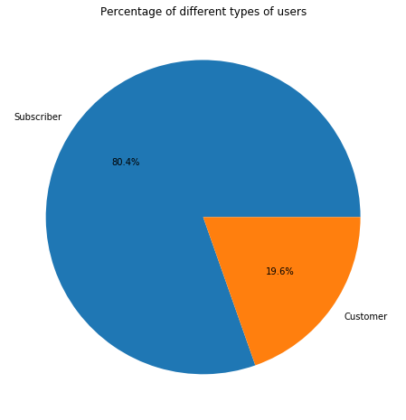

```python
# Create a pie plot with the different percentages of user type
bike_data.user_type.value_counts().plot.pie(autopct='%1.1f%%', figsize=(8,8));
plt.title('Percentage of different types of users')
plt.ylabel('')
plt.show()
```

The pie chart confirms these initial thoughts.

```python
# Check star_month_name stats
bike_data.start_month_name.describe()
```

```
count     2407259
unique         12
top           Mar
freq       256078
Name: start_month_name, dtype: object
```

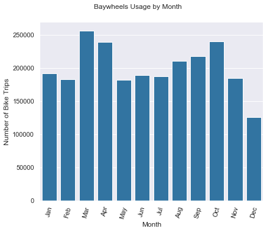

```python
# Monthly usage of the Baywheels Bike system
graph = sns.catplot(data = bike_data, x = 'start_month_name', kind = 'count', color = no_color, aspect=1.25, height=5);

graph.set_axis_labels('Month', 'Number of Bike Trips'),
graph.fig.suptitle('Baywheels Usage by Month', y = 1.05, fontsize = 12);
graph.set_xticklabels(rotation=75);
```

The most popular month is March, with October as the second most popular. April is the third the most popular month to use the baywheels bike system. The weather in San Francisco is best in the mid-late summer and usually stays sunny until returning to its usual foggy weather in the late autumn/early winter months.

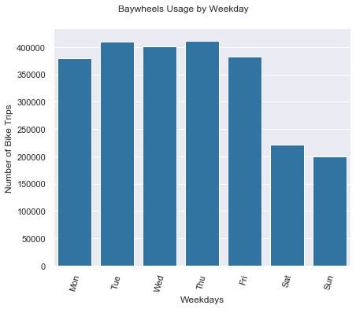

```python
# Weekday usage of the Baywheels bike system
weekday = ['Mon', 'Tue', 'Wed', 'Thu', 'Fri', 'Sat', 'Sun']

graph = sns.catplot(data=bike_data, x='start_time_weekday', kind='count', color = no_color, aspect=1.25, height=5, order = weekday)
graph.set_axis_labels('Weekdays', 'Number of Bike Trips')
graph.fig.suptitle('Baywheels Usage by Weekday', y=1.05, fontsize=12);
graph.set_xticklabels(rotation=75);
```

Tuesdays and Thursdays seem to be the most popular days for using the bike sharing system, however Mondays, Wednesdays and Fridays are very close to the Tues/Thursdays numbers. The usage drops significantly on Saturdays and Sundays suggesting the Baywheels bike share system is used primarily for commuting purposes during working days.

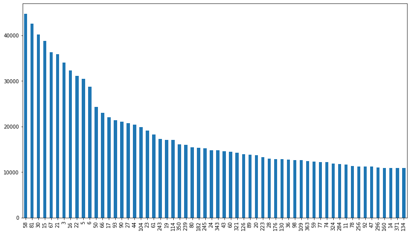

```python
# Bar plot with the top 60 most popular start stations
bike_data.start_station_id.value_counts().head(60).plot(kind='bar', figsize=(14,8));
```

In the plot above we can see that the top five start stations are `58`, `81`, `30`, `15` and `67`are really popular.

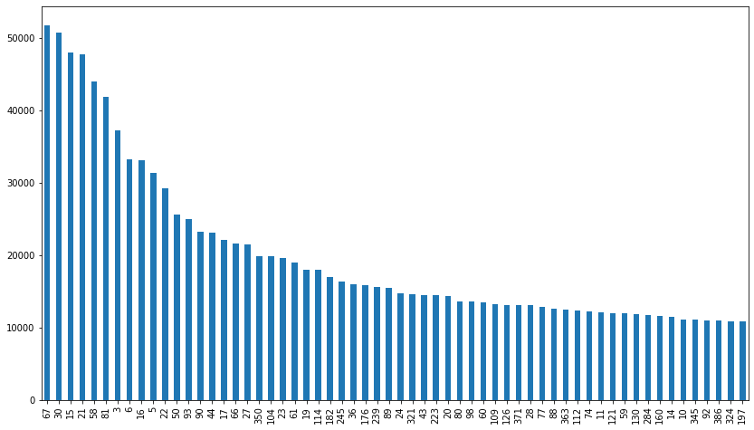

```python
# Bar plot with the top 60 most popular end stations
bike_data.end_station_id.value_counts().head(60).plot(kind='bar', figsize=(14,8));
```

In the plot above we can see that the top five end stations are `67`, `30`, `15`, `21` and `58`are really popular.

This indicates that stations `67`, `58`, `30` and `15` are really popular and the amount of starts and ends is really high.

```python
# Check the Number of unique stations
bike_data.start_station_id.nunique(), bike_data.end_station_id.nunique()
```

```
(434, 435)
```

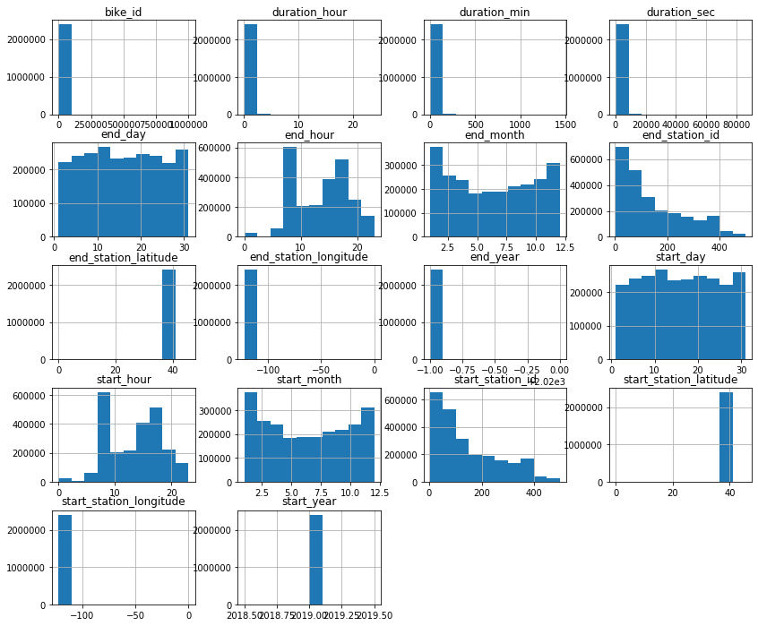

```python
# Create histogram of "bike_data"
bike_data.hist(figsize=(14,12));
```

### Discuss the distribution(s) of your variable(s) of interest. Were there any unusual points? Did you need to perform any transformations?

- We can clearly see that some stations are more frequent than other, in total there are 434 different stations.
- Most of the users type are `Subscribers`.
- Transformation were conducted in the cleaning step.

### Of the features you investigated, were there any unusual distributions? Did you perform any operations on the data to tidy, adjust, or change the form of the data? If so, why did you do this?

- Rows withou station id were removed
- Several columns data types were updated
- Duration was calculated in hours and minutes
- Year, month, day, hour, weekday, start and end date were extracted
- Two new columns were created with month name for start and end month

## 4 - Bivariate Exploration

In this section the relationships between pairs of variables will be investigated

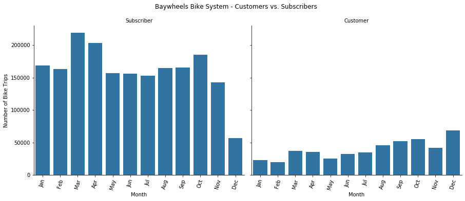

```python
# Is there any difference in the number of rides by month and user type?
graph = sns.catplot(data=bike_data, x='start_month_name', col="user_type", kind='count', sharey = True, color = no_color, aspect=1.25, height=5,);

graph.set_axis_labels("Month", "Number of Bike Trips");
graph.set_titles("{col_name}");
graph.fig.suptitle('Baywheels Bike System - Customers vs. Subscribers', y=1.05, fontsize=12);
graph.set_xticklabels(rotation=75);
```

Customers: demand is high around summertime, reaching its peak in December. Customers are most probably tourists, or the occasional riders who visit the Bay Area.

Subscribers: the highest demand is from March till October. Subscribers are most likely riders using the bikes for their daily commute.

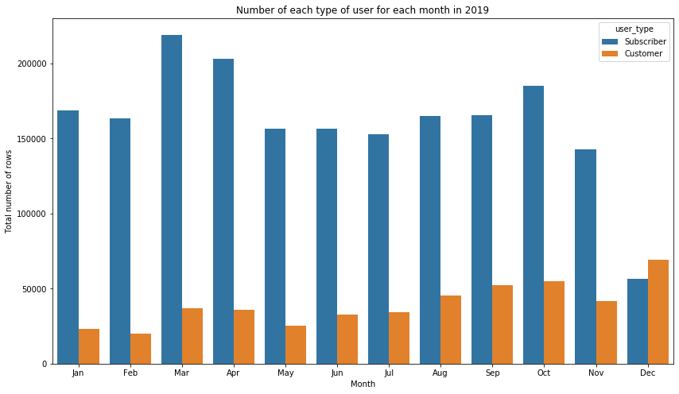

```python
# Plot the amount of users of each type for each month by year
plt.figure(figsize=(14,8));
sns.countplot(data = bike_data, x = 'start_month_name', hue = 'user_type');
plt.xlabel('Month');
plt.ylabel('Total number of rows');
plt.title('Number of each type of user for each month in 2019');
plt.show()
```

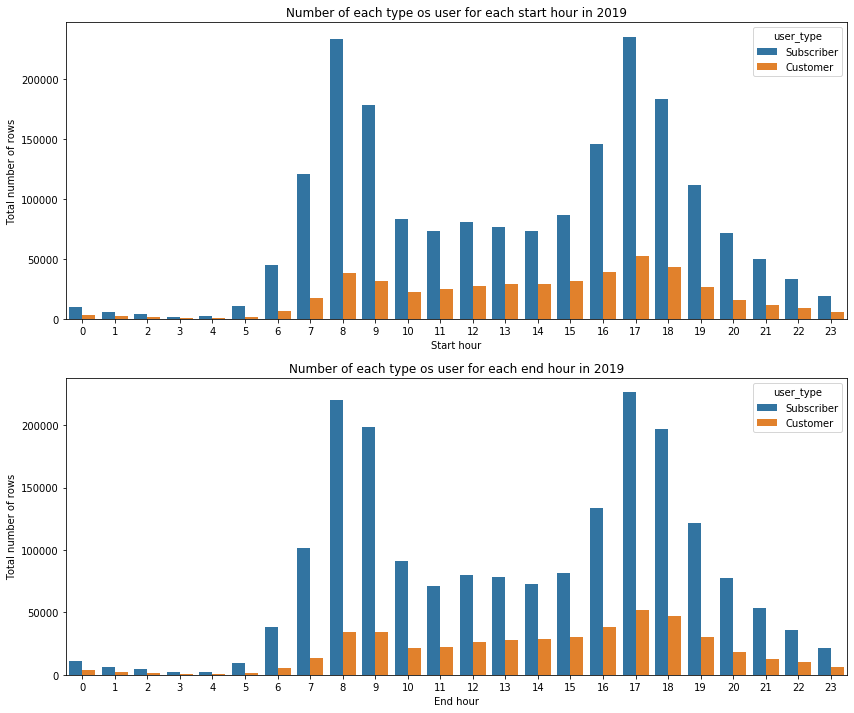

```python
# Plot number of user type by hour
fig, ax = plt.subplots(nrows=2, figsize = [14,12])
sns.countplot(data = bike_data, x = 'start_hour', hue = 'user_type', ax = ax[0]);
sns.countplot(data = bike_data, x = 'end_hour', hue = 'user_type', ax = ax[1]);
ax[0].set_xlabel('Start hour');
ax[0].set_ylabel('Total number of rows');
ax[0].set_title('Number of each type os user for each start hour in 2019');
ax[1].set_xlabel('End hour');
ax[1].set_ylabel('Total number of rows');
ax[1].set_title('Number of each type os user for each end hour in 2019');
plt.show()
```

In this case, as we saw before, there is a high demand at 8-9 am and then at 5 - 6 pm. Basically when the people start and end of the work. If we look on the subscribers and customers, we can see that there are more customers using it at the afternoon compared on the moorning.

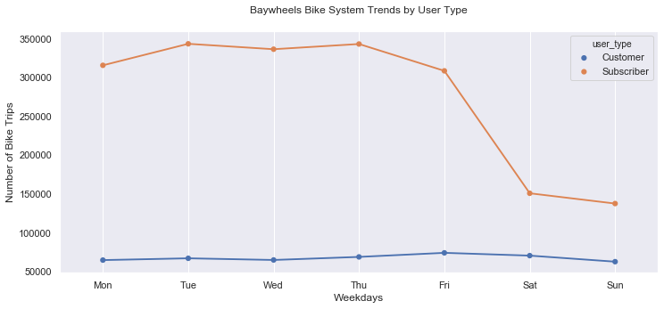

```python
# Customer Usage by Weekday vs. Subscriber Usage by Weekday
plt.figure(figsize=(12, 5))

bike_data_user_week = bike_data.groupby(['start_time_weekday', 'user_type']).size().reset_index()
weekday = ['Mon', 'Tue', 'Wed', 'Thu', 'Fri', 'Sat', 'Sun']

ax = sns.pointplot(data=bike_data_user_week, x='start_time_weekday', y=0, hue = 'user_type', scale=.7, order = weekday);

plt.title('Baywheels Bike System Trends by User Type', y=1.05, fontsize=12)
plt.xlabel('Weekdays')
plt.ylabel('Number of Bike Trips');
plt.grid()
```

The point plot above is an excellent visual showing the sharp contrast between Customers and Subscribers. Customers have a relatively low usage of the bike share system with a small increase on Fridays. Subscribers are the opposite - there is steadily high usage on weekdays, with a sharp decline on the weekend.

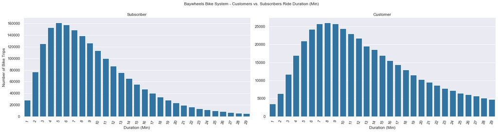

```python
# Customer Usage by Duration vs. Subscriber Usage by Duration
data = bike_data.query('duration_min < 30')

graph = sns.catplot(data=data, x = 'duration_min', col='user_type', kind='count', sharey = False, color = no_color, height=5, aspect=2);
graph.set_axis_labels('Duration (Min)', 'Number of Bike Trips')
graph.set_titles('{col_name}')
graph.fig.suptitle('Baywheels Bike System - Customers vs. Subscribers Ride Duration (Min)', y=1.05, fontsize=12);
graph.set_xticklabels(rotation=75);
```

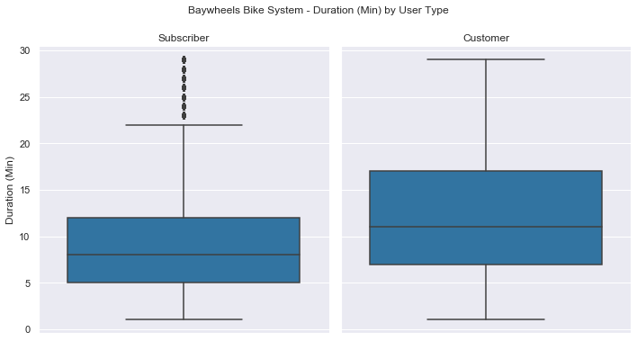

```python
g = sns.catplot(data=data, y='duration_min', col="user_type", kind='box', color = no_color)
g.set_titles(col_template = '{col_name}')
g.set_axis_labels("", "Duration (Min)")
g.fig.suptitle('Baywheels Bike System - Duration (Min) by User Type', y=1.05, fontsize=12);
```

Top 10 Start and End Stations

```python
# Setup function for Top 10 Chart
sns.set(rc={'figure.figsize':(15,8)})
def set_label(xlabel, ylabel):
    plt.xlabel(xlabel)
    plt.ylabel(ylabel)
```

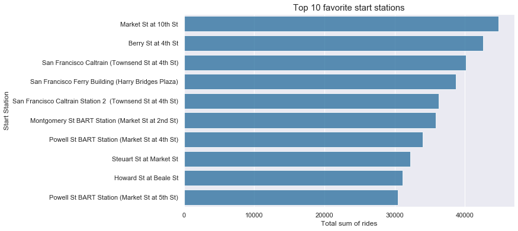

```python
# Top 10 start station based on the count
cnt_srs = bike_data['start_station_name'].value_counts().head(10)
plt.figure(figsize=(10,6))
sns.barplot(y=cnt_srs.index, x=cnt_srs.values, alpha=0.8, color = no_color)
plt.xlabel('Total sum of rides', fontsize=12)
plt.ylabel('Start Station', fontsize=12)
plt.title("Top 10 favorite start stations", fontsize=15)
plt.show()
```

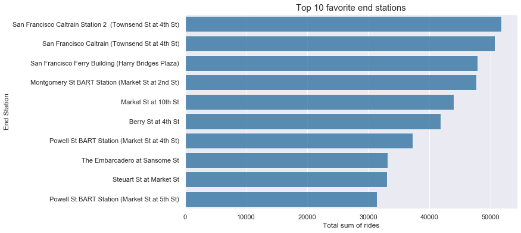

```python
# Top 10 end station based on the count
cnt_srs = bike_data['end_station_name'].value_counts().head(10)
plt.figure(figsize=(10,6))
sns.barplot(y=cnt_srs.index, x=cnt_srs.values, alpha=0.8, color = no_color)
plt.xlabel('Total sum of rides', fontsize=12)
plt.ylabel('End Station', fontsize=12)
plt.title("Top 10 favorite end stations", fontsize=15)
plt.show()
```

```python
# List of the top 10 start stations
list_top10_start_stations = bike_data.query('start_year == 2019').start_station_id.value_counts()[0:10].reset_index()['index']
```

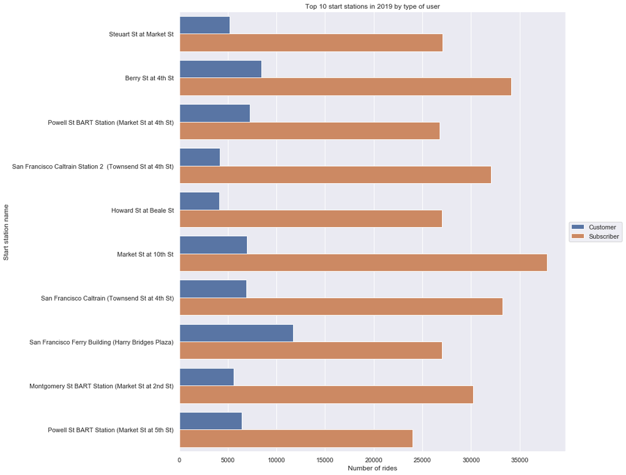

```python
plt.figure(figsize=(12,14));
sns.countplot(data=bike_data.query('(start_year == 2019) and (start_station_id in @list_top10_start_stations)'),\
              y='start_station_name', hue='user_type');

plt.legend(loc='center left', bbox_to_anchor=(1,0.5));
plt.title('Top 10 start stations in 2019 by type of user');
plt.ylabel('Start station name');
plt.xlabel('Number of rides');
```

In the top ten stations the `Subscribers` users are higher when are compared with `Customers` user type.

### Talk about some of the relationships you observed in this part of the investigation. How did the feature(s) of interest vary with other features in the dataset?

`Subscribers` has shorter rides than `Customers`, in the other hand `Subscribers` uses the system more often during the weekdays than weekends. In contrast, the data suggests `Subscribers` are daily commuters or full time students who use the system during weekdays, better weather, and mostly for shorter distances. They mainly rent bikes before and after a typical work or school day (8-9am and 5-6pm).

## 6 - Multivariate Exploration

Additional charts will be created to further analyze the Baywheels data set

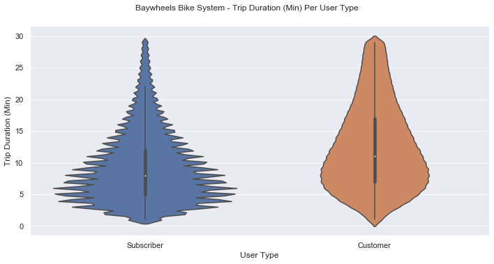

```python
# Violin plot - duration (min) per user type
graph = sns.catplot(data=data, x='user_type', y="duration_min" , kind="violin", height=5, aspect=2);
graph.set_axis_labels("User Type", "Trip Duration (Min)")
graph.fig.suptitle('Baywheels Bike System - Trip Duration (Min) Per User Type', y=1.05, fontsize=12);
```

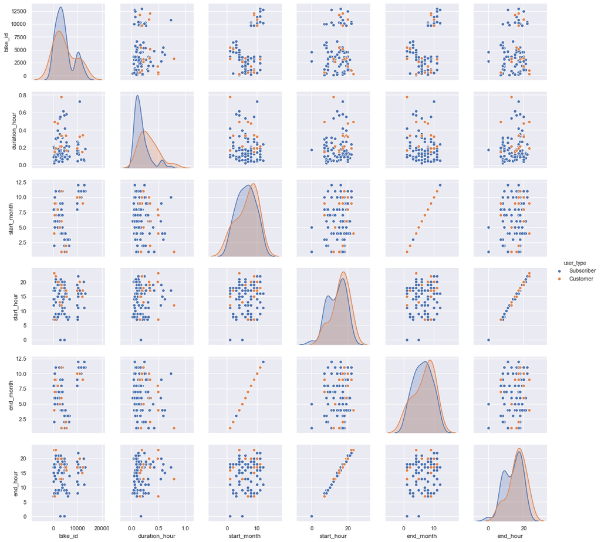

```python
# To generate a plot with good performance I will use a sample size of 100 from the bike_data dataframe

pairplot_chart = bike_data.query('start_year == 2019')[['bike_id','duration_hour','start_month','start_hour', \
                                                     'end_month', 'end_hour', 'user_type']].sample(100)

sns.pairplot(pairplot_chart, hue = 'user_type');
```

## 6 - Summary

This project is a good deal for Lyft and the users, because of the benefits, such as:

- Environmentally friendly, budget friendly, and lifetsyle friendly.
- Subscribers benefit from a health commuting choice
- Customers have a sustainable option for touring the city.
- Affordable and convenient transportation for all people

Renting a bike from the Baywheels Bike System is a fantastic way of moving around in the city, both for enjoyment and work. There are two types of clients using the system: Subscribers and Customers.

## 7 - References

- [StackOverflow 1](https://stackoverflow.com/questions/26942476/reading-csv-zipped-files-in-python) reading zip files
- [StackOverflow 2](https://stackoverflow.com/questions/24870306/how-to-check-if-a-column-exists-in-pandas) check the column existance
- [Github 1](https://github.com/shravankoninti/Udacity_DataAnalyst/blob/master/Project_5_Visualization/Exploratory_visualization.ipynb) Github Reference 1
- [Github 2](https://github.com/chelseymarie6/Communicate-Data-Findings/blob/master/CommunicateData.ipynb) Github Reference 2
- [Github 3](https://github.com/kzhang789/Communicate-data-findings/blob/master/fordgobike_exploration.ipynb) Github Reference 3
- [Github 4](https://github.com/somya1212/Communicate-Ford-Bike-Data-Findings/blob/master/exploration_template_notebook.ipynb) Github Reference 4

Note: The Github references were used to develop this project, some lines of codes and thought process were used to succesfully complete this deliverable.